# Portfolio 2 - Reproducing the existing work

```python
# Loading the libraries
import sys
sys.path.append("../used_functions")
import custom_functions as custfun
import importlib
importlib.reload(custfun)
import pandas as pd
from pandas.plotting import scatter_matrix
import numpy as np
from matplotlib import pyplot as plt
plt.style.use("ggplot")
import matplotlib.dates as mdates
import seaborn as sns
import matplotlib as mpl
from sklearn import linear_model
from sklearn.model_selection import KFold, RepeatedKFold, cross_val_score
from sklearn.metrics import mean_absolute_error, mean_squared_error, r2_score
from sklearn.feature_selection import RFE
```

```python
# Reading the data
training = pd.read_csv("training.csv")
testing = pd.read_csv("testing.csv")
training["date"] = pd.to_datetime(training["date"])
testing["date"] = pd.to_datetime(testing["date"])
```

## 1. EXPLORARION

```python
print(training.shape)
print(testing.shape)
```

```
(14803, 32)
(4932, 32)
```

```python
# % data in training
print("% of data in training dataset : ", str(round(training.shape[0]/(training.shape[0] + testing.shape[0]) * 100))+"%")
# % data in testing
print("% of data in testing dataset : ", str(round(testing.shape[0]/(training.shape[0] + testing.shape[0]) * 100))+"%")
```

```
% of data in training dataset :  75%
% of data in testing dataset :  25%
```

Data is partitioned in two parts [training->75\% and testing 25\%] as mentioned in the paper.

### Setting matplotlib parameters

```python
mpl.rcParams['axes.titlesize'] = 22                                                 # -Change title size of a plot
mpl.rcParams['axes.labelsize'] = 16                                                 # -Change label size(x and y) of a plot
mpl.rcParams['xtick.labelsize'] = 15                                                # -Change xticks size of a plot
mpl.rcParams['ytick.labelsize'] = 15                                                # -Change yticks size of a plot
```

### Graph 1

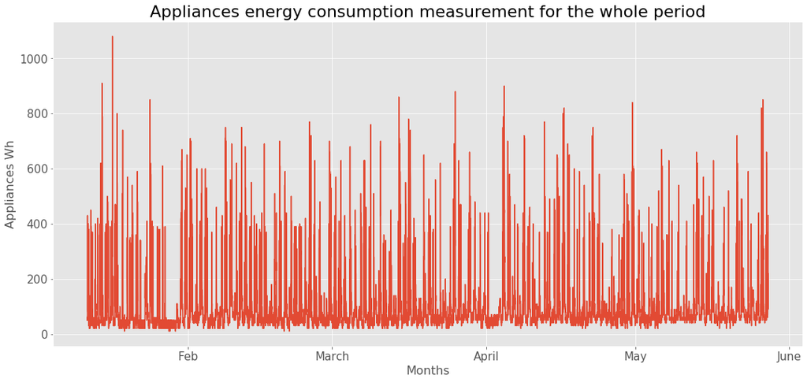

```python
# Plotting the figure
plt.figure(figsize=(18,8))

# Adding the line plot to figure
plt.plot(training["date"], training["Appliances"])

# Setting plot parameters like xtick locators and labels
plt.gca().xaxis.set_major_locator(mdates.MonthLocator())
plt.gca().set_xticklabels(["Feb","March", "April", "May", "June"])
plt.setp(plt.gca().get_xticklabels(),rotation = 0)

# Setting x-axis, y-axis labels and title of the plot
plt.xlabel("Months")
plt.ylabel("Appliances Wh")
plt.title("Appliances energy consumption measurement for the whole period")

plt.show()
```

### Graph 2

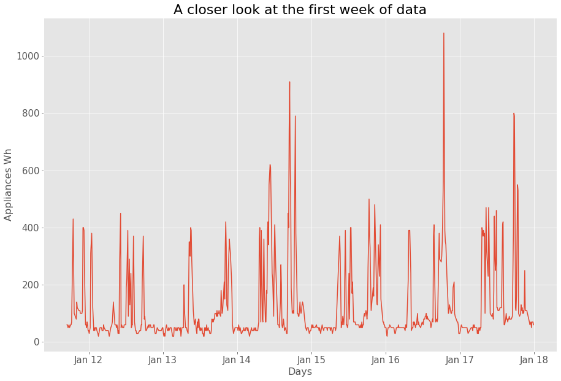

```python
# Mapping string_to_int function to get weeks
data_weeks = pd.Series(map(custfun.string_to_int, training["date"].dt.strftime('%W')))

# Finding from which week data is starting
min_week = min(data_weeks)

# Filtering data of where week = min_week
flag_week1 = (data_weeks == min_week)
first_week = training.loc[flag_week1]

# Plotting the figure
plt.figure(figsize=(15,10))

# Adding the line plot to figure
plt.plot(first_week["date"], first_week["Appliances"])

# Setting plot parameters like xtick locators and labels
plt.gca().xaxis.set_major_locator(mdates.DayLocator())
plt.gca().xaxis.set_major_formatter(mdates.DateFormatter('Jan %d'))
plt.setp(plt.gca().get_xticklabels(),rotation = 0)

# Setting x-axis, y-axis labels and title of the plot
plt.xlabel("Days")
plt.ylabel("Appliances Wh")
plt.title("A closer look at the first week of data")

plt.show()
```

### Graph Explanation

The appliances’ consumption profile is highly variable as seen in above plot, with periods of almost constant demand followed by high spikes.

### Graph 3

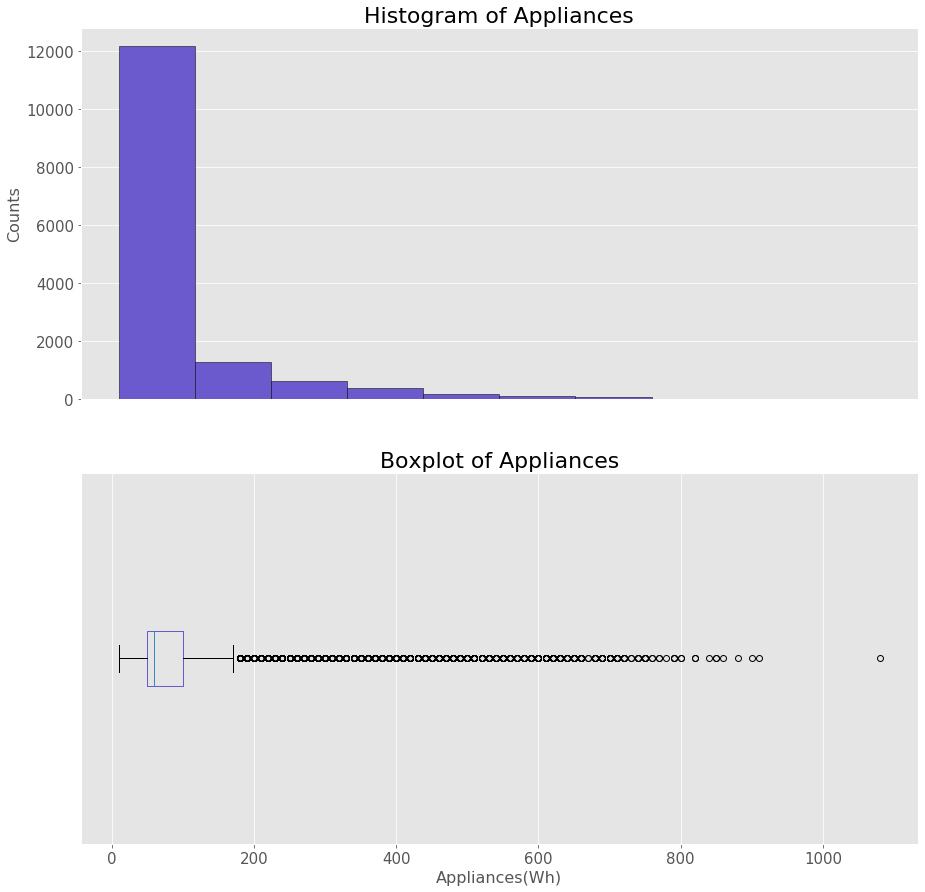

```python
# For more detials about this function check used_function/custom_functions.py
custfun.create_histogram_plus_boxplot(training["Appliances"], "Appliances", "slateblue", "Counts", "Appliances(Wh)", (15,15))
```

### Graph 4

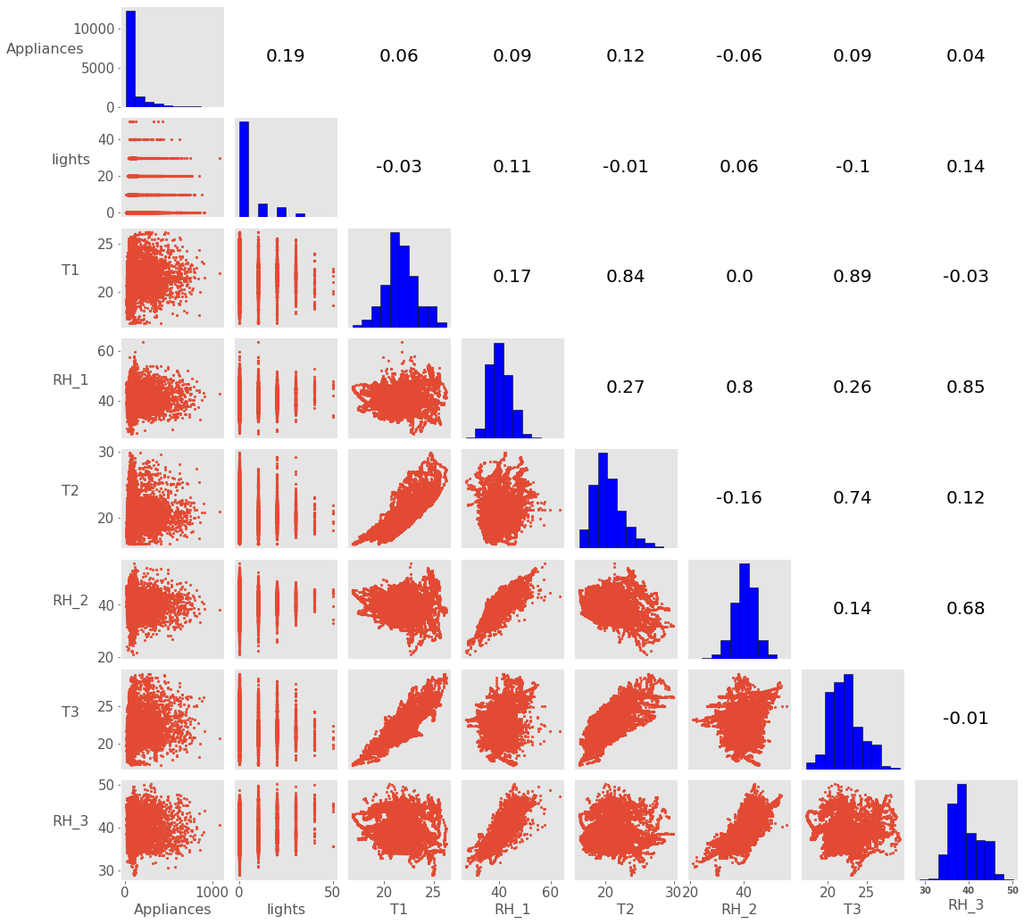

```python
# For more detials about this function check used_function/custom_functions.py
custfun.create_scatter_matrix(training[["Appliances", "lights", "T1", "RH_1", "T2", "RH_2", "T3", "RH_3"]])
```

### Graph Explanation

Plot shows that there is a positive correlation between the energy consumption of appliances and lights (0.19). The second largest correlation is between appliances and T2. For the indoor temperatures, the correlations are high as expected. For example, a positive correlation is found with T1 and T3.

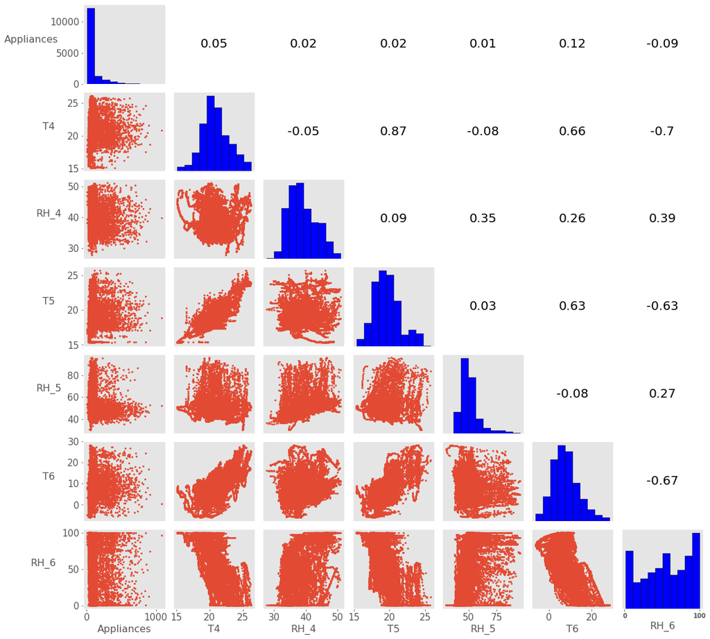

```python
# For more detials about this function check used_function/custom_functions.py
custfun.create_scatter_matrix(training[["Appliances", "T4", "RH_4", "T5", "RH_5", "T6", "RH_6"]])
```

### Graph Explanation

Plot shows that the highest correlation with the appliances is between the outdoor temperature (0.12). There is also a negative correlation between the appliances and outdoor humidity/RH6 (−0.09)

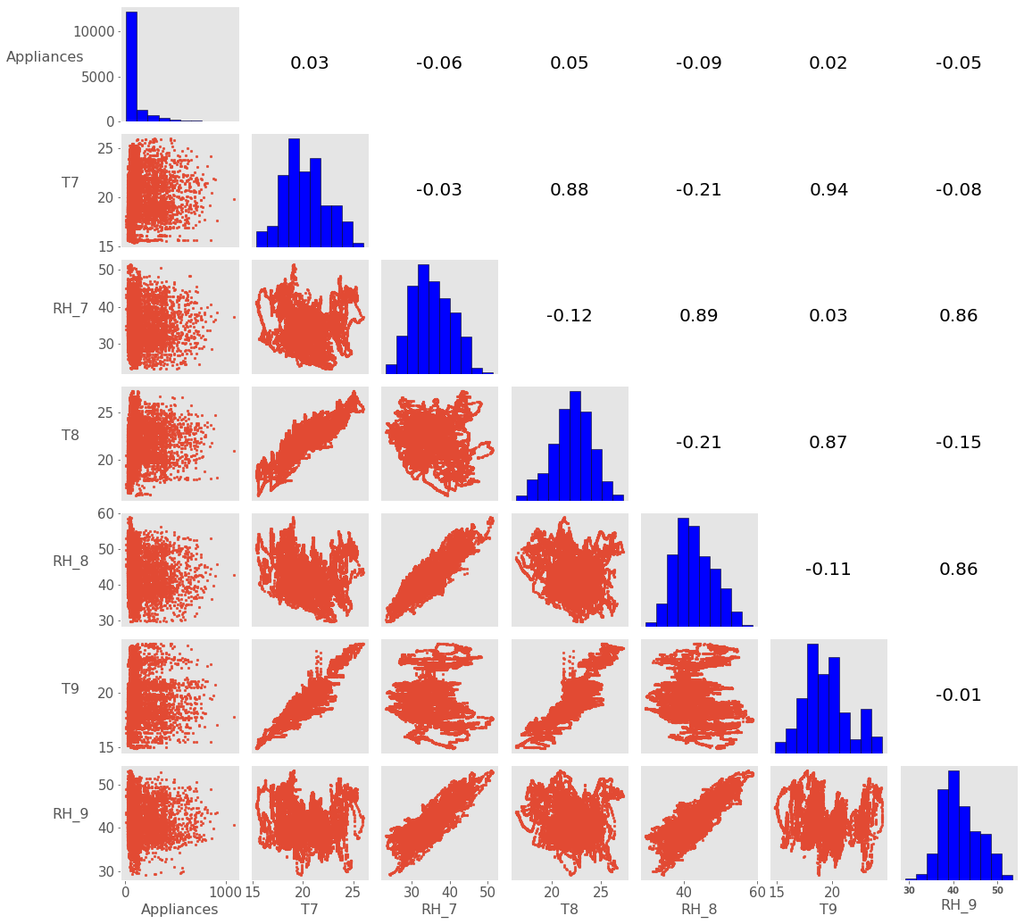

```python
# For more detials about this function check used_function/custom_functions.py
custfun.create_scatter_matrix(training[["Appliances", "T7", "RH_7", "T8", "RH_8", "T9", "RH_9"]])
```

### Graph Explanation

Plot shows positive correlations between the consumption of appliances and T7, T8 and T9 being 0.03, 0.05 and 0.02 respectively and negative correlation with RH_7(-0.06), RH_8(-0.09), RH_9(-0.05). The consumption of appliances have postive correlations with temperatures and negative correlation with Humidities.

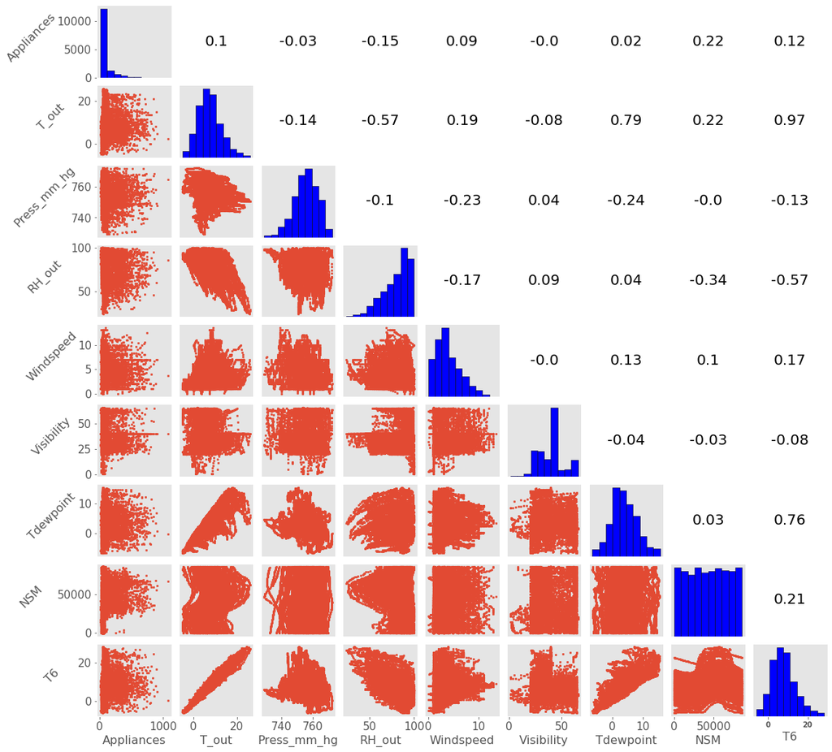

```python
# For more detials about this function check used_function/custom_functions.py
custfun.create_scatter_matrix(training[["Appliances", "T_out", "Press_mm_hg", "RH_out", "Windspeed",
       "Visibility", "Tdewpoint", "NSM", "T6"]], ylab_rotation = 45)
```

### Graph Exaplanation

Plot shows the highest correlation between the energy consumption of appliances and NSM with a value of 0.22. A positive correlation of 0.10 is seen between appliances’ consumption and outdoor temperature (Tout) that is, the higher temperatures, the higher the energy use by the appliances. Also there is a positive correlation with appliances’ consumption and wind speed (0.09), higher wind speeds correlate with higher energy consumption by the appliances. A negative correlation of −0.15 was found with the RHout, and of −0.03 with pressure. Another important and interesting correlation is between the pressure and the wind speed. This relationship is negative (−0.23). The linear trend is with lower pressure the wind speed will be higher.

```python
# Getting different dataframes for first four weeks from the data
## For more detials about this function check used_function/custom_functions.py
first_week_appliances_df = custfun.create_weekdata(training, 1)
second_week_appliances_df = custfun.create_weekdata(training, 2)
third_week_appliances_df = custfun.create_weekdata(training, 3)
forth_week_appliances_df = custfun.create_weekdata(training, 4)

# We don't have data for first week in January. Data starts from Monday from 17th hour.
first_week_appliances_df
```

| date | Monday | Tuesday | Wednesday | Thursday | Friday | Saturday | Sunday |
| --- | --- | --- | --- | --- | --- | --- | --- |
| 0 | NaN | 470.0 | 190.0 | 190.0 | 320.0 | 240.0 | 180.0 |
| 1 | NaN | 590.0 | 190.0 | 190.0 | 210.0 | 210.0 | 250.0 |
| 2 | NaN | 180.0 | 180.0 | 260.0 | 280.0 | 150.0 | 120.0 |
| 3 | NaN | 140.0 | 190.0 | 180.0 | 180.0 | 200.0 | 50.0 |
| 4 | NaN | 230.0 | 270.0 | 110.0 | 240.0 | 210.0 | 310.0 |
| 5 | NaN | 170.0 | 210.0 | 130.0 | 240.0 | 50.0 | 220.0 |
| 6 | NaN | 120.0 | 350.0 | 210.0 | 220.0 | 260.0 | 270.0 |
| 7 | NaN | 220.0 | 330.0 | 1290.0 | 140.0 | 1000.0 | 1920.0 |
| 8 | NaN | 520.0 | 1210.0 | 690.0 | 50.0 | 380.0 | 1270.0 |
| 9 | NaN | 260.0 | 1190.0 | 1010.0 | 800.0 | 310.0 | 1060.0 |
| 10 | NaN | 820.0 | 310.0 | 2540.0 | 310.0 | 350.0 | 360.0 |
| 11 | NaN | 330.0 | 360.0 | 1040.0 | 620.0 | 120.0 | 1910.0 |
| 12 | NaN | 950.0 | 210.0 | 960.0 | 1120.0 | 390.0 | 460.0 |
| 13 | NaN | 710.0 | 210.0 | 170.0 | 450.0 | 520.0 | 650.0 |
| 14 | NaN | 560.0 | 230.0 | 780.0 | 250.0 | 180.0 | 760.0 |
| 15 | NaN | 170.0 | 250.0 | 210.0 | 280.0 | 1180.0 | 490.0 |
| 16 | NaN | 150.0 | 480.0 | 1850.0 | 340.0 | 300.0 | 330.0 |
| 17 | 280.0 | 930.0 | 490.0 | 2320.0 | 590.0 | 670.0 | 2600.0 |
| 18 | 190.0 | 250.0 | 580.0 | 1000.0 | 1670.0 | 2570.0 | 1470.0 |
| 19 | 870.0 | 220.0 | 560.0 | 670.0 | 440.0 | 2350.0 | 420.0 |
| 20 | 450.0 | 260.0 | 1360.0 | 660.0 | 830.0 | 340.0 | 660.0 |
| 21 | 520.0 | 250.0 | 1360.0 | 570.0 | 610.0 | 720.0 | 470.0 |
| 22 | 1540.0 | 130.0 | 760.0 | 190.0 | 790.0 | 400.0 | 130.0 |
| 23 | 340.0 | 210.0 | 100.0 | 200.0 | 310.0 | 260.0 | 320.0 |

I have printed above dataframe just to show that there is no data before hour 17 on first day of the data

### Graph 5

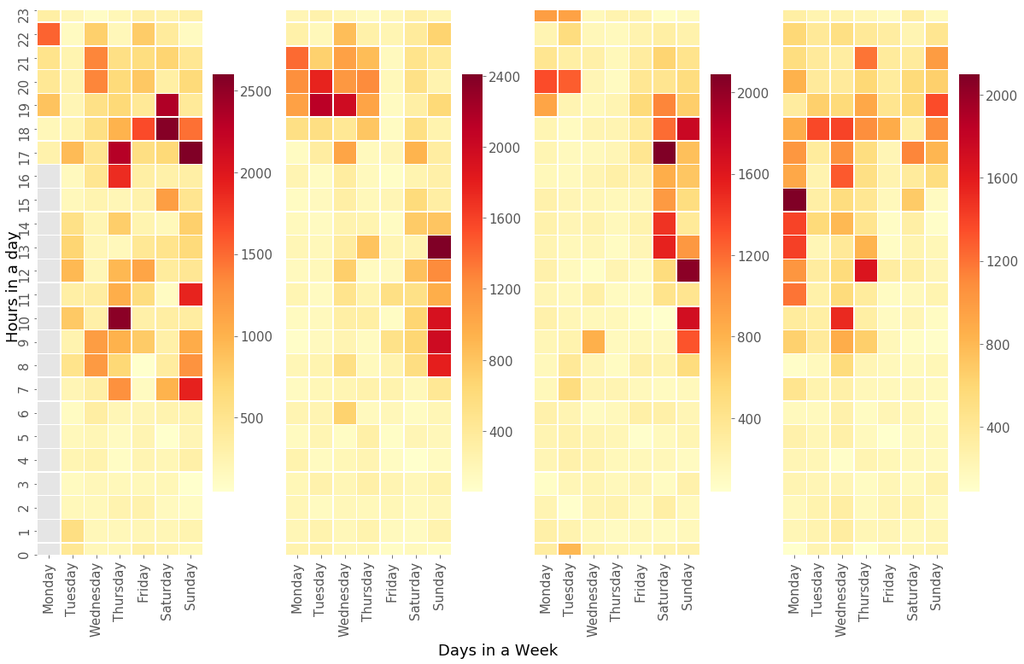

```python
# Plotting the figure
fig = plt.figure(figsize = (20,20))

# Adding four subplots - each for each week
ax1 = fig.add_subplot(141)
ax2 = fig.add_subplot(142)
ax3 = fig.add_subplot(143)
ax4 = fig.add_subplot(144)

# Plotting heatmap for each week
sns.heatmap(first_week_appliances_df.sort_index(ascending = False), cmap = "YlOrRd", ax = ax1,
            square = True, cbar_kws = {"shrink" : 0.45}, linewidths = 0.5)
sns.heatmap(second_week_appliances_df.sort_index(ascending = False), cmap = "YlOrRd", ax = ax2,
            square = True, cbar_kws = {"shrink" : 0.45}, linewidths = 0.5)
sns.heatmap(third_week_appliances_df.sort_index(ascending = False), cmap = "YlOrRd", ax = ax3,
            square = True, cbar_kws = {"shrink" : 0.45}, linewidths = 0.5)
sns.heatmap(forth_week_appliances_df.sort_index(ascending = False), cmap = "YlOrRd", ax = ax4,
            square = True, cbar_kws = {"shrink" : 0.45}, linewidths = 0.5)

# Removing labels and ticks from the axes
ax1.set_ylabel('');ax1.set_xlabel('')

ax2.set_ylabel('');ax2.set_xlabel('');ax2.set_yticks([]);ax2.set_yticklabels([])

ax3.set_ylabel('');ax3.set_xlabel('');ax3.set_yticks([]);ax3.set_yticklabels([])

ax4.set_ylabel('');ax4.set_xlabel('');ax4.set_yticks([]);ax4.set_yticklabels([])

# Setting x-axis and y-axis label for plot
fig.text(0.5, 0.20, "Days in a Week", fontsize = 18, ha = 'center')
fig.text(0.1, 0.5, "Hours in a day", fontsize = 18, va = 'center', rotation = 'vertical')

plt.show()
```

### Graph Explanation

The energy consumption starts to rise around 6 in the morning. Then around noon, there are energy load surges. The energy demand also increases around 6 pm. There is no clear pattern regarding the day of the week

### Grey box means we don't have data for that hour. I can replace this NAN values with zero but Author of the paper didn't mention that in the paper.

## 2. MODELING

```python
# Taking all the columns as mentioned in the paper
training_modified_1 = training.copy()
training_modified_1 = training_modified_1.iloc[:, 1:]
training_modified_1["WeekStatus"] = training_modified_1["WeekStatus"].astype("category")
training_modified_1["Day_of_week"] = training_modified_1["Day_of_week"].astype("category")

# Getting categorical columns and convert them to codes
categorical_cols = training_modified_1.select_dtypes(['category']).columns
training_modified_1[categorical_cols] = training_modified_1[categorical_cols].apply(lambda x: x.cat.codes)

# Taking all the columns as mentioned in the paper
testing_modified_1 = testing.copy()
testing_modified_1 = testing_modified_1.iloc[:, 1:]
testing_modified_1["WeekStatus"] = testing_modified_1["WeekStatus"].astype("category")
testing_modified_1["Day_of_week"] = testing_modified_1["Day_of_week"].astype("category")

# Getting categorical columns and convert them to codes
categorical_cols = testing_modified_1.select_dtypes(['category']).columns
testing_modified_1[categorical_cols] = testing_modified_1[categorical_cols].apply(lambda x: x.cat.codes)

# Taking x(independent) and y(dependent) variables for models, train for training and test for testing
x_train = training_modified_1.iloc[:, 1:]
y_train = training_modified_1.iloc[:, 0]
x_test = testing_modified_1.iloc[:, 1:]
y_test = testing_modified_1.iloc[:, 0]
```

```python
# Creating the linear model
paper_model = linear_model.LinearRegression()

# Fitting the training data
paper_model.fit(x_train, y_train)
```

```
LinearRegression(copy_X=True, fit_intercept=True, n_jobs=None,
         normalize=False)
```

### Model Performance for Training

```python
# Predicting the values for training data
predicted_train = paper_model.predict(x_train)

# Calculating various metrics for evaluation purposes
rmse_train = mean_squared_error(y_train, predicted_train) ** 0.5
mae_train = mean_absolute_error(y_train, predicted_train)
## For more detials about this function check used_function/custom_functions.py
mape_train = custfun.mean_absolute_percentage_error(y_train, predicted_train)
r2_train = r2_score(y_train, predicted_train)

# Printing metrics given in paper
print("RMSE(Root Mean Squared Error):", round(rmse_train, 2))
print("R Squared:", round(r2_train, 2))
print("MAE(Mean Absolute Error):", round(mae_train, 2))
print("MAPE(Mean Absolute Percentage Error):", round(mape_train, 2))
```

```
RMSE(Root Mean Squared Error): 93.29
R Squared: 0.18
MAE(Mean Absolute Error): 53.31
MAPE(Mean Absolute Percentage Error): 61.73
```

#### Got same results as in paper for training data.

### Model Performance for Testing

```python
# Predicting the values for testing data
predicted_test = paper_model.predict(x_test)

# Calculating various metrix for evaluation purposes
rmse_test = mean_squared_error(y_test, predicted_test) ** 0.5
mae_test = mean_absolute_error(y_test, predicted_test)
## For more detials about this function check used_function/custom_functions.py
mape_test = custfun.mean_absolute_percentage_error(y_test, predicted_test)
r2_test = r2_score(y_test, predicted_test)

# Printing metrics
print("RMSE(Root Mean Squared Error):", round(rmse_test, 2))
print("R Squared:", round(r2_test, 2))
print("MAE(Mean Absolute Error):", round(mae_test, 2))
print("MAPE(Mean Absolute Percentage Error):", round(mape_test, 2))
```

```
RMSE(Root Mean Squared Error): 93.33
R Squared: 0.16
MAE(Mean Absolute Error): 52.16
MAPE(Mean Absolute Percentage Error): 60.32
```

#### Got same results as in paper for testing data.

### Residuals plot

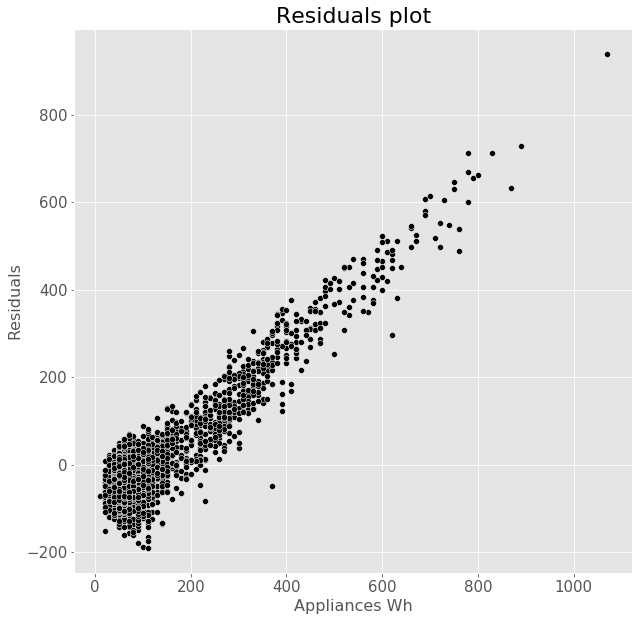

```python
# Plotting the figure
plt.figure(figsize = (10,10))

# Adding the scatter plot of residuals vs original value
plt.scatter(y_test, (y_test - predicted_test), c = "black", edgecolors = "white", marker = "o")

# Setting x-axis, y-axis label and title of the plot
plt.xlabel("Appliances Wh")
plt.ylabel("Residuals")
plt.title("Residuals plot")

plt.show()
```

### Graph Explanation

Plot shows a residual plot for the linear regression model. The residuals were computed as the difference between the real values and the predicted values. From plot above, it is obvious that the relationship between the variables and the energy consumption of appliances is not well represented by the linear model since the residuals are not normally distributed around the horizontal axis.

## 3. RFE

```python
# Creating new dictionary for creating dataframe from it
dictionary = {}

# Some lists to create the columns in dataframe
variables_chosen, no_variables_chosen = [], []
rmse, mae, mape, r2 = [], [], [], []

# Looping over to get various #variable for RFE
for i in range(len(x_train.columns), 0, -1):

    # Creating the RFE
    rfe = RFE(paper_model, n_features_to_select = i, step = 1)

    # Fitting the RFE
    rfe_model = rfe.fit(x_train, y_train)

    # Predicting using rfe model
    predicted = rfe_model.predict(x_test)

    # Appending some information to the lists
    no_variables_chosen.append(i)
    variables_chosen.append(", ".join(x_train.columns.values[list(rfe_model.support_)]))
    rmse.append(mean_squared_error(y_test, predicted) ** 0.5)
    mae.append(mean_absolute_error(y_test, predicted))
    ## For more detials about this function check used_function/custom_functions.py
    mape.append(custfun.mean_absolute_percentage_error(y_test, predicted))
    r2.append(r2_score(y_test, predicted))

# Adding keys and values to dictionary
dictionary["variables_chosen"] = variables_chosen
dictionary["no_variables_chosen"] = no_variables_chosen
dictionary["rmse"] = rmse
dictionary["mae"] = mae
dictionary["mape"] = mape
dictionary["r2"] = r2
```

```python
# Creating dataframe from the dictionary
model_information = pd.DataFrame.from_dict(dictionary)
```

```python
# Sorting dataframe based on r2 values
model_information = model_information.sort_values("r2", ascending = False)
```

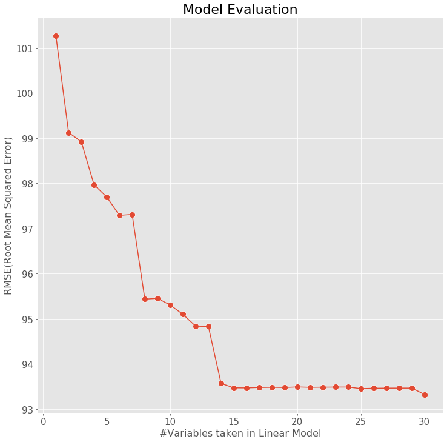

```python
# Plotting RMSE vs No of variables
# For more detials about this function check used_function/custom_functions.py
custfun.plot_RMSE_VS_NoVar(df = model_information)
```

```python
model_information.head()
```

|  | variables_chosen | no_variables_chosen | rmse | mae | mape | r2 |
| --- | --- | --- | --- | --- | --- | --- |
| 0 | lights, T1, RH_1, T2, RH_2, T3, RH_3, T4, RH_4... | 30 | 93.328781 | 52.157240 | 60.322326 | 0.156255 |
| 5 | lights, T1, RH_1, T2, RH_2, T3, RH_3, T4, RH_4... | 25 | 93.456502 | 52.270019 | 60.403636 | 0.153944 |
| 4 | lights, T1, RH_1, T2, RH_2, T3, RH_3, T4, RH_4... | 26 | 93.463714 | 52.242983 | 60.345830 | 0.153813 |
| 3 | lights, T1, RH_1, T2, RH_2, T3, RH_3, T4, RH_4... | 27 | 93.467029 | 52.209217 | 60.312623 | 0.153753 |
| 2 | lights, T1, RH_1, T2, RH_2, T3, RH_3, T4, RH_4... | 28 | 93.467705 | 52.222808 | 60.339592 | 0.153741 |

## Experimenting with the Linear Model

### Training data

```python
# Creating new training dataframes for the experimental purposes
training_modified_2 = training.copy()

# Creating dummies instead of using categorical codes
dummies_weekstatus = pd.get_dummies(training_modified_2.loc[:, "WeekStatus"])
dummies_dow = pd.get_dummies(training_modified_2.loc[:, "Day_of_week"])

# Appending the dummies columns to dataframe
training_modified_2 = pd.concat([training_modified_2, dummies_weekstatus, dummies_dow], axis = 1)

# Dropping one dummy variable from each column as well as dropping categorical columns
training_modified_2 = training_modified_2.drop(["Weekend", "WeekStatus", "Day_of_week", "Monday"], axis = 1)

# Creating new column for hour
training_modified_2["hour"] = training_modified_2["date"].dt.hour

training_modified_2.head()
```

|  | date | Appliances | lights | T1 | RH_1 | T2 | RH_2 | T3 | RH_3 | T4 | ... | rv2 | NSM | Weekday | Friday | Saturday | Sunday | Thursday | Tuesday | Wednesday | hour |
| --- | --- | --- | --- | --- | --- | --- | --- | --- | --- | --- | --- | --- | --- | --- | --- | --- | --- | --- | --- | --- | --- |
| 0 | 2016-01-11 17:00:00 | 60 | 30 | 19.89 | 47.596667 | 19.2 | 44.790000 | 19.79 | 44.730000 | 19.000000 | ... | 13.275433 | 61200 | 1 | 0 | 0 | 0 | 0 | 0 | 0 | 17 |
| 1 | 2016-01-11 17:10:00 | 60 | 30 | 19.89 | 46.693333 | 19.2 | 44.722500 | 19.79 | 44.790000 | 19.000000 | ... | 18.606195 | 61800 | 1 | 0 | 0 | 0 | 0 | 0 | 0 | 17 |
| 2 | 2016-01-11 17:20:00 | 50 | 30 | 19.89 | 46.300000 | 19.2 | 44.626667 | 19.79 | 44.933333 | 18.926667 | ... | 28.642668 | 62400 | 1 | 0 | 0 | 0 | 0 | 0 | 0 | 17 |
| 3 | 2016-01-11 17:40:00 | 60 | 40 | 19.89 | 46.333333 | 19.2 | 44.530000 | 19.79 | 45.000000 | 18.890000 | ... | 10.084097 | 63600 | 1 | 0 | 0 | 0 | 0 | 0 | 0 | 17 |
| 4 | 2016-01-11 17:50:00 | 50 | 40 | 19.89 | 46.026667 | 19.2 | 44.500000 | 19.79 | 44.933333 | 18.890000 | ... | 44.919484 | 64200 | 1 | 0 | 0 | 0 | 0 | 0 | 0 | 17 |

5 rows × 38 columns

### Testing data

```python
# Creating new testing dataframes for the experimental purposes
testing_modified_2 = testing.copy()

# Creating dummies instead of using categorical codes
dummies_weekstatus = pd.get_dummies(testing_modified_2.loc[:,"WeekStatus"])
dummies_dow = pd.get_dummies(testing_modified_2.loc[:,"Day_of_week"])

# Appending the dummies columns to dataframe
testing_modified_2 = pd.concat([testing_modified_2, dummies_weekstatus, dummies_dow], axis = 1)

# Dropping one dummy variable from each column as well as dropping categorical columns
testing_modified_2 = testing_modified_2.drop(["Weekend","WeekStatus","Day_of_week","Monday"], axis = 1)

# Creating new column for hour
testing_modified_2["hour"] = testing_modified_2["date"].dt.hour

testing_modified_2.head()
```

|  | date | Appliances | lights | T1 | RH_1 | T2 | RH_2 | T3 | RH_3 | T4 | ... | rv2 | NSM | Weekday | Friday | Saturday | Sunday | Thursday | Tuesday | Wednesday | hour |
| --- | --- | --- | --- | --- | --- | --- | --- | --- | --- | --- | --- | --- | --- | --- | --- | --- | --- | --- | --- | --- | --- |
| 0 | 2016-01-11 17:30:00 | 50 | 40 | 19.890000 | 46.066667 | 19.200000 | 44.590000 | 19.79 | 45.000000 | 18.89 | ... | 45.410389 | 63000 | 1 | 0 | 0 | 0 | 0 | 0 | 0 | 17 |
| 1 | 2016-01-11 18:00:00 | 60 | 50 | 19.890000 | 45.766667 | 19.200000 | 44.500000 | 19.79 | 44.900000 | 18.89 | ... | 47.233763 | 64800 | 1 | 0 | 0 | 0 | 0 | 0 | 0 | 18 |
| 2 | 2016-01-11 18:40:00 | 230 | 70 | 19.926667 | 45.863333 | 19.356667 | 44.400000 | 19.79 | 44.900000 | 18.89 | ... | 10.298729 | 67200 | 1 | 0 | 0 | 0 | 0 | 0 | 0 | 18 |
| 3 | 2016-01-11 18:50:00 | 580 | 60 | 20.066667 | 46.396667 | 19.426667 | 44.400000 | 19.79 | 44.826667 | 19.00 | ... | 8.827838 | 67800 | 1 | 0 | 0 | 0 | 0 | 0 | 0 | 18 |
| 4 | 2016-01-11 19:30:00 | 100 | 10 | 20.566667 | 53.893333 | 20.033333 | 46.756667 | 20.10 | 48.466667 | 19.00 | ... | 24.884962 | 70200 | 1 | 0 | 0 | 0 | 0 | 0 | 0 | 19 |

5 rows × 38 columns

### Creating splits for the model

```python
# Taking x(independent) and y(dependent) variables for models, train for training and test for testing
train_x = training_modified_2.iloc[:, 2:]
test_x = testing_modified_2.iloc[:, 2:]
train_y = training_modified_2.iloc[:, 1]
test_y = testing_modified_2.iloc[:, 1]
```

## Modelling

```python
# Creating linear regression model
tem_model = linear_model.LinearRegression()

# Fitting training data
tem_model.fit(train_x, train_y)
```

```
LinearRegression(copy_X=True, fit_intercept=True, n_jobs=None,
         normalize=False)
```

### Model Performance

```python
# Predicting the values for testing data
predicted_test = tem_model.predict(test_x)

# Calculating various metrix for evaluation purposes
rmse_test = mean_squared_error(test_y, predicted_test) ** 0.5
mae_test = mean_absolute_error(test_y, predicted_test)
## For more detials about this function check used_function/custom_functions.py
mape_test = custfun.mean_absolute_percentage_error(test_y, predicted_test)
r2_test = r2_score(test_y, predicted_test)

# Printing metrics
print("RMSE(Root Mean Squared Error):", round(rmse_test, 2))
print("R Squared:", round(r2_test, 2))
print("MAE(Mean Absolute Error):", round(mae_test, 2))
print("MAPE(Mean Absolute Percentage Error):", round(mape_test, 2))
```

```
RMSE(Root Mean Squared Error): 93.16
R Squared: 0.16
MAE(Mean Absolute Error): 51.99
MAPE(Mean Absolute Percentage Error): 59.96
```

### RFE

```python
# Creating new dictionary for creating dataframe from it
dictionary = {}

# Some lists to create the columns in dataframe
variables_chosen, no_variables_chosen = [], []
rmse, mae, mape, r2 = [], [], [], []

# Looping over to get various #variable for RFE
for i in range(len(train_x.columns), 0, -1):

    # Creating the RFE
    rfe = RFE(tem_model, n_features_to_select = i, step = 1)

    # Fitting the RFE
    rfe_model = rfe.fit(train_x, train_y)

    # Predicting using rfe model
    predicted = rfe_model.predict(test_x)

    # Appending some information to the lists
    no_variables_chosen.append(i)
    variables_chosen.append(", ".join(train_x.columns.values[list(rfe_model.support_)]))
    rmse.append(mean_squared_error(test_y, predicted) ** 0.5)
    mae.append(mean_absolute_error(test_y, predicted))
    ## For more detials about this function check used_function/custom_functions.py
    mape.append(custfun.mean_absolute_percentage_error(test_y, predicted))
    r2.append(r2_score(test_y, predicted))

# Adding keys and values to dictionary
dictionary["variables_chosen"] = variables_chosen
dictionary["no_variables_chosen"] = no_variables_chosen
dictionary["rmse"] = rmse
dictionary["mae"] = mae
dictionary["mape"] = mape
dictionary["r2"] = r2
```

```python
# Creating dataframe from the dictionary
model_information_2 = pd.DataFrame.from_dict(dictionary)
```

```python
# Sorting dataframe based on r2 values
model_information_2 = model_information_2.sort_values("r2", ascending = False)
```

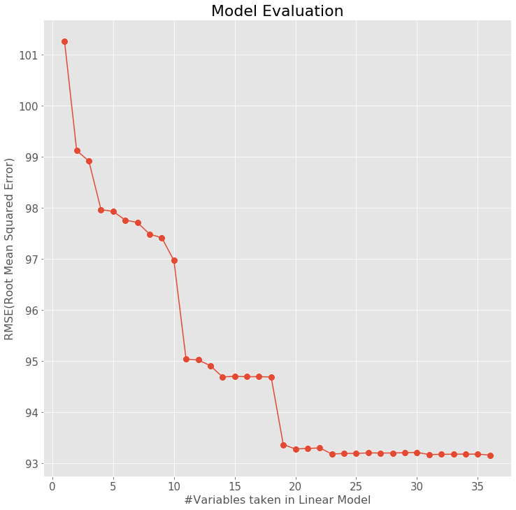

```python
# Plotting RMSE vs No of variables
# For more detials about this function check used_function/custom_functions.py
custfun.plot_RMSE_VS_NoVar(df = model_information_2)
```

```python
model_information_2.head()
```

|  | variables_chosen | no_variables_chosen | rmse | mae | mape | r2 |
| --- | --- | --- | --- | --- | --- | --- |
| 0 | lights, T1, RH_1, T2, RH_2, T3, RH_3, T4, RH_4... | 36 | 93.163470 | 51.985929 | 59.955435 | 0.159241 |
| 5 | lights, T1, RH_1, T2, RH_2, T3, RH_3, T4, RH_4... | 31 | 93.175087 | 52.018301 | 59.983445 | 0.159031 |
| 4 | lights, T1, RH_1, T2, RH_2, T3, RH_3, T4, RH_4... | 32 | 93.177736 | 51.987624 | 59.961395 | 0.158984 |
| 3 | lights, T1, RH_1, T2, RH_2, T3, RH_3, T4, RH_4... | 33 | 93.182177 | 51.975326 | 59.935284 | 0.158903 |
| 2 | lights, T1, RH_1, T2, RH_2, T3, RH_3, T4, RH_4... | 34 | 93.182521 | 51.985096 | 59.954496 | 0.158897 |